# 2020 Suncorp Super Netball Analysis

Emily Partridge

2023-03-12

```r
# Load required packages
library(readr)
library(tidyverse)
library(kableExtra)
library(ggdark)

# Load in the performance data
RawData <- read_csv("Data/Dataset3_Assessment3.csv")
```

# General Play Turnovers

#### 20 athletes with the most 2020 season general play turnovers

```r
# Create a summary table of performance data
RawData %>%
  filter(Statistic=="generalPlayTurnovers") %>%
  group_by(Athlete, Team) %>%
  summarise(Sum = round(sum(Total), 1)) %>%
  arrange(desc(Sum)) %>%
  head(20) %>%
  mutate(across(where(is.numeric), round, 1)) %>%
  kbl() %>%
  kable_minimal()
```

| Athlete | Team | Sum |
| --- | --- | --- |
| Austin, K | GIANTS Netball | 75 |
| Aiken, R | Queensland Firebirds | 62 |
| Horjus, G | Adelaide Thunderbirds | 58 |
| Scherian, L | Sunshine Coast Lightning | 58 |
| Dwan, T | Queensland Firebirds | 57 |
| Charles, V | West Coast Fever | 54 |
| Teague-Neeld, A | West Coast Fever | 54 |
| Jovic, M | Collingwood Magpies | 53 |
| Pitman, C | Adelaide Thunderbirds | 53 |
| Cassidy, M | Queensland Firebirds | 52 |
| Langman, L | Sunshine Coast Lightning | 52 |
| Nelson, S | Collingwood Magpies | 52 |
| Wallace, S | NSW Swifts | 52 |
| Harten, J | GIANTS Netball | 51 |
| Price, J | GIANTS Netball | 51 |
| Watson, L | Melbourne Vixens | 50 |
| Wood, S | Sunshine Coast Lightning | 49 |
| Sinclair, G | Collingwood Magpies | 48 |
| Haythornthwaite, N | NSW Swifts | 45 |
| Potgieter, L | Adelaide Thunderbirds | 43 |

### Summary of team general play turnovers for the 2020 season

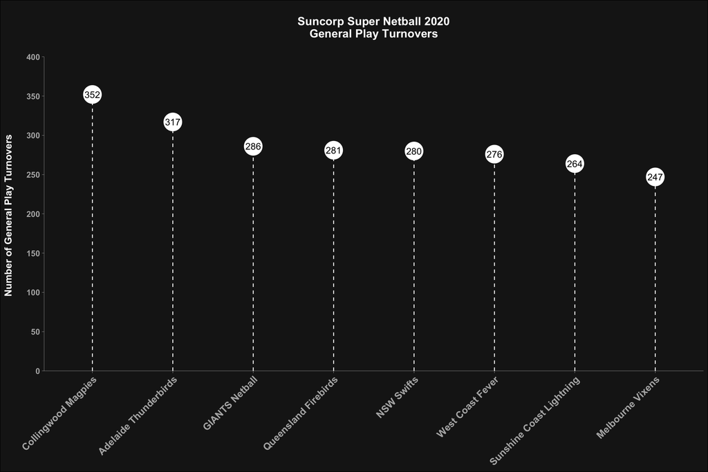

```r
# Create a plot for sum of GPT over season for each team
RawData %>% filter(Statistic=="generalPlayTurnovers") %>% group_by(Team) %>% summarise(Sum = round(sum(Total), 1)) %>%
  arrange(desc(Sum)) %>% ggplot(aes(x = reorder(Team, -Sum), y = Sum)) +
  geom_point(size = 10) + geom_segment(aes(x = Team, y = 0, xend = Team, yend = Sum), linetype = "dashed") +
  geom_text(aes(label = Sum), size = 4, colour = "black", check_overlap = TRUE) +
  scale_y_continuous(expand = c(0,0), limits = c(0, 400), breaks = seq(0,500, by = 50)) +
  labs(x = NULL, y = "Number of General Play Turnovers \n", title = "\n Suncorp Super Netball 2020 \n General Play Turnovers \n") +
  dark_theme_gray()  + theme(plot.title = element_text(size = 14, face = "bold", hjust = 0.5),
        plot.background = element_rect(fill = "grey10"), panel.background = element_blank(),
        panel.grid.major = element_blank(), panel.grid.minor = element_blank(), legend.background = element_blank(),
        axis.title.y = element_text(size = 12, face = "bold"), axis.ticks.x =  element_line(color = "white", size = 0.1),
        axis.line.x =  element_line(color = "white", size = 0.1),
        axis.text.x = element_text(size = 12, face = "bold", angle = 45, vjust = 1, hjust = 1),
        axis.ticks.y =  element_line(color = "white", size = 0.1), axis.line.y =  element_line(color = "white", size = 0.1),
        axis.text.y = element_text(size = 10, face = "bold"),legend.title = element_blank(), legend.position = "none")
```

# Successful Goals From Zone 1

#### Summary of all 2020 season goal scorers

```r
# Remove zeros from data frame
RawData_new <- filter_if(RawData, is.numeric, all_vars((.) != 0))

# Create a summary table of individual goals in zone 1 data
RawData_new %>%
  filter(Statistic=="goal_from_zone1") %>%
  group_by(Athlete, Team) %>%
  summarise(Sum = round(sum(Total), 1)) %>%
  arrange(desc(Sum)) %>%
  mutate(across(where(is.numeric), round, 1)) %>%
  kbl() %>%
  kable_minimal()
```

| Athlete | Team | Sum |
| --- | --- | --- |
| Fowler, J | West Coast Fever | 782 |
| Aiken, R | Queensland Firebirds | 577 |
| Koenen, C | Sunshine Coast Lightning | 450 |
| Wallace, S | NSW Swifts | 442 |
| Potgieter, L | Adelaide Thunderbirds | 431 |
| Nelson, S | Collingwood Magpies | 407 |
| Kumwenda, M | Melbourne Vixens | 328 |
| Harten, J | GIANTS Netball | 239 |
| Thwaites, C | Melbourne Vixens | 218 |
| Austin, K | GIANTS Netball | 207 |
| Bassett, C | GIANTS Netball | 192 |
| Philip, T | Melbourne Vixens | 162 |
| Wood, S | Sunshine Coast Lightning | 151 |
| Dwan, T | Queensland Firebirds | 139 |
| Garbin, S | NSW Swifts | 135 |
| Horjus, G | Adelaide Thunderbirds | 133 |
| Housby, H | NSW Swifts | 130 |
| Proscovia, P | Sunshine Coast Lightning | 118 |
| Ryde, E | Collingwood Magpies | 105 |
| Sinclair, G | Collingwood Magpies | 94 |
| Teague-Neeld, A | West Coast Fever | 54 |
| Glasgow, S | Adelaide Thunderbirds | 46 |
| Stanton, K | West Coast Fever | 18 |
| Allen, N | Collingwood Magpies | 16 |
| Gooden, S | Adelaide Thunderbirds | 12 |
| Singleton, K | NSW Swifts | 8 |
| Venter, I | Queensland Firebirds | 6 |
| Haythornthwaite, N | NSW Swifts | 3 |
| Hunt, B | Sunshine Coast Lightning | 3 |
| Letherbarrow, M | GIANTS Netball | 3 |
| Stower, M | Queensland Firebirds | 3 |
| Cosh, E | West Coast Fever | 2 |
| Hodges, C | Adelaide Thunderbirds | 1 |
| Lawrie, A | Sunshine Coast Lightning | 1 |

### 2020 season successful shots in zone 1 by team

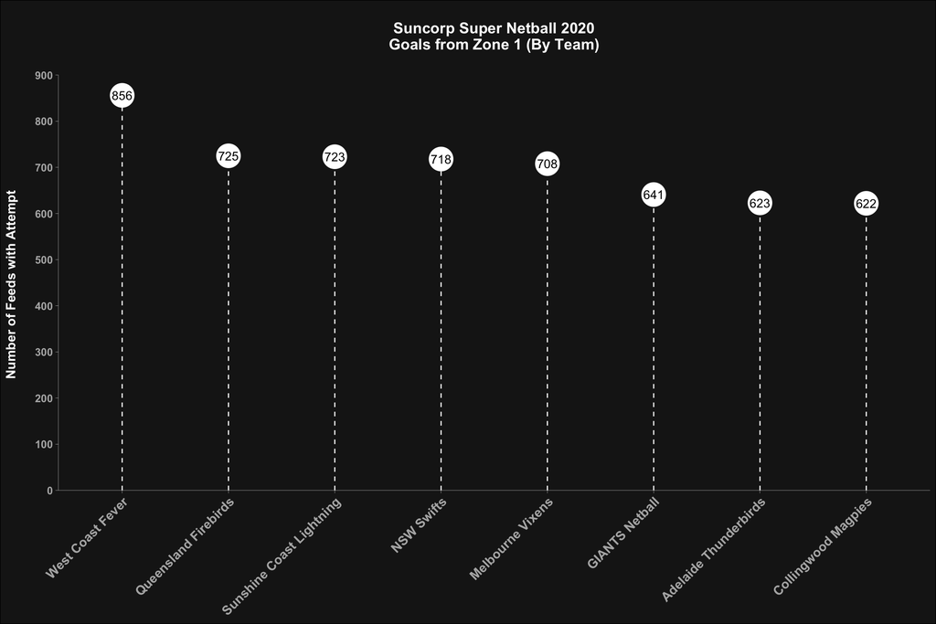

```r
#  Plot the top 10 athletes for statistics = goal_from_zone1
RawData %>% filter(Statistic=="goal_from_zone1") %>% group_by(Team) %>% summarise(Sum = round(sum(Total), 1)) %>%
  arrange(desc(Sum)) %>% ggplot(aes(x = reorder(Team, -Sum), y = Sum)) +
  geom_point(size = 10) + geom_segment(aes(x = Team, y = 0, xend = Team, yend = Sum), linetype = "dashed") +
  geom_text(aes(label = Sum), size = 4, colour = "black", check_overlap = TRUE) +
  scale_y_continuous(expand = c(0,0), limits = c(0, 900), breaks = seq(0,900, by = 100)) +
  labs(x = NULL, y = "Number of Feeds with Attempt \n", title = "\n Suncorp Super Netball 2020 \n Goals from Zone 1 (By Team) \n") +
  dark_theme_gray()  + theme(plot.title = element_text(size = 14, face = "bold", hjust = 0.5),
        plot.background = element_rect(fill = "grey10"), panel.background = element_blank(),
        panel.grid.major = element_blank(), panel.grid.minor = element_blank(), legend.background = element_blank(),
        axis.title.y = element_text(size = 12, face = "bold"), axis.ticks.x =  element_line(color = "white", size = 0.1),
        axis.line.x =  element_line(color = "white", size = 0.1),
        axis.text.x = element_text(size = 12, face = "bold", angle = 45, vjust = 1, hjust = 1),
        axis.ticks.y =  element_line(color = "white", size = 0.1), axis.line.y =  element_line(color = "white", size = 0.1),
        axis.text.y = element_text(size = 10, face = "bold"),legend.title = element_blank(), legend.position = "none")
```

#### Question 4a: What was the first thing you did when you loaded the dataset? Summary statistics? A visualisation? Exploratory data analysis?

First thing I completed after importing the data was to create a tibble of the data for exploratory data analysis by looking at the first and last 10 rows using the head() and tail() functions. I filtered the data to look at the two variables of generalPlayTurnovers and goal_from_zone1 using the filter() function. I then used the ggplot() function to do a quick exploratory scatter plot to view the ranges of the variables.

#### Question 4b: How did you choose to explore the data? Did you perform any summary statistics to help you further explore the data?

For both data variables explored (goal_from_zone1 and generalPlayTurnovers) I used sum() function to get the totals by athlete or team.

#### Question 4c: What packages did you use to visualise data?

- tidyverse to use the ggplot2, dyplr, %>% functions to tidy and present the data in tables and plots
- kableExtra package was used for the table visualisation
- ggdark for the plot aesthetic colours that are also colour blind friendly

#### Question 4d: Did you encounter any issues? Errors? How did you overcome them?

I also had an issue with the data not being presented in the plot of goal_from_zone1 but no errors indicating why, so took a little while to realise that it was simply due to the y-axis limits needing to be increased to show the data!

#### Question 4e: Do you have any interpretations/ find anything interesting from that dataset that coaches, athletes or performance staff might be able to use in their practice?

Regarding general play turnovers, staff may be able to focus on athletes that have high rates of turnovers during in-season games for training drills to improve these statistics moving forward. Ideally, a dataset for a single game could include statistics for each quarter and player position to delve deeper into the rates of turnovers by athlete.